# MTH6139 Time Series

Coursework 1 - Chasing Championships: McLaren in F1

Nicole D’Souza

Spring Term | March 2026

[figure not shown]

# Section 1: Introduction 🏎️

[figure not shown]

*McLaren MCL38 at the 2024 Mexico City Grand Prix*

McLaren’s story is one of the most dramatic in motorsport. With back to back titles in the late 1980s with Ayrton Senna and Alain Prost, a challenging decade, and their 2024 Constructors Championship, McLaren’s journey is one of the greatest comeback stories in Formula 1.

In this project I analyse McLaren’s Formula 1 Constructors Championship points from 1966 to 2024 using Meta’s Prophet forecasting system.

The data was sourced from official Formula 1 constructor standings records available at formula1.com. Note it does not include their Constructor Championship victory in 2025 and their driver Lando Norris’ WDC victory.

The goal of this project is to:

1. Explore McLaren’s performance over nearly 60 years of Formula 1
2. Identify key eras of dominance and decline
3. Use Prophet to model the trend and forecast future performance

# Section 2: Loading and Exploring the Data

## 2.1 Loading the Data

```r
mclaren_data <- read.csv("data/mclaren.csv")
head(mclaren_data)
```

```
##   year points position wins
## 1 1966      3        9    0
## 2 1967      3       10    0
## 3 1968     52        2    3
## 4 1969     40        4    1
## 5 1970     35        5    0
## 6 1971     10        6    0
```

```r
cat("Years covered:", min(mclaren_data$year), "to", max(mclaren_data$year), "\n")
```

```
## Years covered: 1966 to 2024
```

```r
cat("Total seasons:", nrow(mclaren_data), "\n")
```

```
## Total seasons: 59
```

```r
cat("Best points total:", max(mclaren_data$points),
    "in", mclaren_data$year[which.max(mclaren_data$points)], "\n")
```

```
## Best points total: 666 in 2024
```

```r
cat("Worst points total:", min(mclaren_data$points),
    "in", mclaren_data$year[which.min(mclaren_data$points)], "\n")
```

```
## Worst points total: 0 in 2007
```

## 2.2 Interactive Points Chart

```r
library(plotly)
library(ggplot2)

mclaren_eras <- mclaren_data
mclaren_eras$era <- ifelse(mclaren_eras$year < 1980, "Early Years",
                    ifelse(mclaren_eras$year < 1994, "Golden Era (Senna/Prost)",
                    ifelse(mclaren_eras$year < 2010, "Mixed Results",
                    ifelse(mclaren_eras$year < 2015, "Button/Hamilton Era",
                    ifelse(mclaren_eras$year < 2022, "Dark Years & Recovery",
                    "Norris Era")))))

mclaren_points_plot <- ggplot(mclaren_eras, aes(x = year, y = points,
                               colour = era,
                               text = paste("Year:", year,
                                           "<br>Points:", points,
                                           "<br>Wins:", wins,
                                           "<br>Position:", position))) +
  geom_line(colour = "grey80", size = 0.8) +
  geom_point(size = 2.5) +
  scale_colour_manual(values = c(
    "Early Years"              = "red",
    "Golden Era (Senna/Prost)" = "orange",
    "Mixed Results"            = "yellow",
    "Button/Hamilton Era"      = "green",
    "Dark Years & Recovery"    = "blue",
    "Norris Era"               = "purple"
  )) +
  labs(title = "McLaren F1 Constructor Points (1966-2024)",
       x = "Year", y = "Championship Points", colour = "Era") +
  theme_minimal()

ggplotly(mclaren_points_plot, tooltip = "text")
```

[interactive chart not shown]

> Hover to see the year, points, wins and championship position. You can also click eras to show/hide them!✨

The chart shows three distinct phases that stand out immediately:

- The Golden Era (1984-1993) where McLaren dominated with Senna and Prost
- The Dark Years (2015-2018) where the Honda engine partnership collapsed
- The 2024 Norris Era which produced McLaren’s best ever points total

Looking at the chart, the initial red dots from the 1960s and 1970s sit low and flat, Mclaren were a solid team in this period but not the dominant team that they would become.

From 1984 onwards the orange Golden Era dots move upwards and stay there for around a decade.

The yellow Mixed Results era shows more variation. McLaren could still challenge at the front but were far less consistent than the Golden Era. The dot sitting near zero around 2007 is worth noting as this was the year McLaren were disqualified from the Constructors’ Championship following the spygate scandal, despite their drivers finishing first and second in the Drivers’ standings.

The blue Dark Years cluster show the points dropping as low as 27 in 2015 during the troubled Honda partnership before a gradual recovery through 2019 to 2022.

## 2.3 Championship Wins Over Time

```r
mclaren_wins_plot <- ggplot(mclaren_data, aes(x = year, y = wins,
                                text = paste("Year:", year, "<br>Wins:", wins))) +
  geom_col(fill = "orange", alpha = 0.8) +
  labs(title = "McLaren Race Wins Per Season (1966-2024)",
       x = "Year", y = "Number of Race Wins") +
  theme_minimal()

ggplotly(mclaren_wins_plot, tooltip = "text")
```

[interactive chart not shown]

McLaren won 15 out of 16 races during the 1988 season, setting a record that is still in place today. 🏆

The most obvious thing about the plot is the gap between 2013 and 2021 showing 9 years without a single win that reflects just how far McLaren had fallen.

## 2.4 Linear Trend

To understand the overall trend, I fitted a simple linear regression.

```r
mclaren_lm <- lm(points ~ year, data = mclaren_data)
summary(mclaren_lm)
```

```
##
## Call:
## lm(formula = points ~ year, data = mclaren_data)
##
## Residuals:
##     Min      1Q  Median      3Q     Max
## -175.37  -57.25   -7.72   25.80  432.80
##
## Coefficients:
##               Estimate Std. Error t value Pr(>|t|)
## (Intercept) -7812.6470  1611.5369  -4.848 1.00e-05 ***
## year            3.9752     0.8078   4.921 7.69e-06 ***
## ---
## Signif. codes:  0 '***' 0.001 '**' 0.01 '*' 0.05 '.' 0.1 ' ' 1
##
## Residual standard error: 105.7 on 57 degrees of freedom
## Multiple R-squared:  0.2982, Adjusted R-squared:  0.2859
## F-statistic: 24.22 on 1 and 57 DF,  p-value: 7.693e-06
```

```r
mclaren_trend_plot <- ggplot(mclaren_data, aes(x = year, y = points)) +
  geom_point(colour = "orange", size = 2) +
  geom_smooth(method = "lm", colour = "pink", se = TRUE) +
  labs(title = "McLaren Points with Linear Trend",
       x = "Year", y = "Championship Points") +
  theme_minimal()

ggplotly(mclaren_trend_plot)
```

[interactive chart not shown]

The linear model shows a slight upward trend, but the R-squared value is low, meaning a straight line is a poor fit for this data.

This makes sense because McLaren’s performance has gone through dramatic cycles rather than a steady growth.

This is why Prophet is more suitable than a simple linear model.

# Section 3: Preparing Data for Prophet

Prophet requires a dataframe with two specific columns:

- `ds` — dates
- `y` — values

Since this is annual data, I have converted the year column to a date format.

```r
mclaren_prophet_df <- data.frame(
  ds = as.Date(paste0(mclaren_data$year, "-01-01")),
  y  = mclaren_data$points
)

head(mclaren_prophet_df)
```

```
##           ds  y
## 1 1966-01-01  3
## 2 1967-01-01  3
## 3 1968-01-01 52
## 4 1969-01-01 40
## 5 1970-01-01 35
## 6 1971-01-01 10
```

Each year now has a corresponding date in the right format, so Prophet can read it properly.

# Section 4: How Prophet Works

Prophet was developed by Meta’s Core Data Science team in 2017. It decomposes a time series into three components:

$$y(t) = g(t) + s(t) + h(t) +
\epsilon_t$$

Where:

- $g(t)$ is the trend: the long-term direction
- $s(t)$ is the seasonality: repeating patterns
- $h(t)$ is the holiday effect: special events
- $\epsilon_t$ is the error term

For annual data like this, there is no weekly or daily seasonality, only the long-term trend matters.

```r
mclaren_prophet_model <- prophet::prophet(
  mclaren_prophet_df,
  yearly.seasonality  = FALSE,
  weekly.seasonality  = FALSE,
  daily.seasonality   = FALSE,
  changepoint.prior.scale = 0.5
)
```

I have set `changepoint.prior.scale = 0.5` to allow Prophet to be more flexible in detecting the dramatic shifts in McLaren’s performance over the decades. A higher value gives Prophet more freedom to pick up on these kinds of sudden changes, which makes it a much better fit for this data.

This is why all three seasonality parameters are set to FALSE, with one data point per year, there are simply no repeating sub-annual patterns for Prophet to detect.

Prophet is particularly well suited to this dataset because it handles irregular trends and sudden changes in direction well, which is something simpler models like linear regression struggle with, as we saw in Section 2.4.

# Section 5: Forecasting McLaren’s Future

## 5.1 Generating the Forecast

I have forecasted McLaren’s points for the next 10 seasons.

```r
mclaren_future <- prophet::make_future_dataframe(
  mclaren_prophet_model,
  periods = 10,
  freq    = "year"
)

mclaren_forecast <- predict(mclaren_prophet_model, mclaren_future)

tail(mclaren_forecast[c("ds", "yhat", "yhat_lower", "yhat_upper")], 10)
```

```
##            ds     yhat yhat_lower yhat_upper
## 60 2025-01-01 263.2061   131.6208   405.7465
## 61 2026-01-01 269.1816   142.6925   399.0625
## 62 2027-01-01 275.1572   144.0825   413.5153
## 63 2028-01-01 281.1327   159.0267   406.3603
## 64 2029-01-01 287.1246   159.7558   424.2671
## 65 2030-01-01 293.1002   164.0571   429.6013
## 66 2031-01-01 299.0757   160.2845   437.8566
## 67 2032-01-01 305.0513   166.2611   434.4606
## 68 2033-01-01 311.0432   177.9718   447.7482
## 69 2034-01-01 317.0187   180.8723   432.7845
```

## 5.2 Comparing Prophet Configurations

To explore how sensitive the forecast is to the `changepoint.prior.scale` parameter, I fitted a second Prophet model using a much lower value of 0.1. A lower value makes the trend more rigid and less responsive to sudden shifts in the data.

```r
mclaren_prophet_model_rigid <- prophet::prophet(
  mclaren_prophet_df,
  yearly.seasonality      = FALSE,
  weekly.seasonality      = FALSE,
  daily.seasonality       = FALSE,
  changepoint.prior.scale = 0.1
)

mclaren_future_rigid <- prophet::make_future_dataframe(
  mclaren_prophet_model_rigid,
  periods = 10,
  freq    = "year"
)

mclaren_forecast_rigid <- predict(mclaren_prophet_model_rigid, mclaren_future_rigid)
```

```r
library(xts)
library(dygraphs)

actual_xts     <- xts(mclaren_data$points,
                      order.by = as.Date(paste0(mclaren_data$year, "-01-01")))
forecast_flex  <- xts(mclaren_forecast$yhat,
                      order.by = as.Date(mclaren_forecast$ds))
forecast_rigid <- xts(mclaren_forecast_rigid$yhat,
                      order.by = as.Date(mclaren_forecast_rigid$ds))

mclaren_comparison <- merge(actual_xts, forecast_flex, forecast_rigid)
names(mclaren_comparison) <- c("Actual", "Flexible (0.5)", "Rigid (0.1)")

dygraph(mclaren_comparison,
        main = "Prophet Forecast Comparison: Flexible vs Rigid Trend") %>%
  dySeries("Actual",         label = "Actual Points",        color = "orange",    strokeWidth = 2) %>%
  dySeries("Flexible (0.5)", label = "Flexible Model (0.5)", color = "red",   strokeWidth = 2) %>%
  dySeries("Rigid (0.1)",    label = "Rigid Model (0.1)",    color = "blue", strokeWidth = 2) %>%
  dyOptions(fillAlpha = 0.1) %>%
  dyRangeSelector() %>%
  dyLegend(show = "always")
```

[interactive chart not shown]

The two models produce noticeably different forecasts.

The rigid model (0.1) struggles to follow McLaren’s dramatic swings, it smooths over the Honda crisis and underestimates the speed of the 2024 recovery.

This shows that the choice of `changepoint.prior.scale` has a real impact on the forecast, and for data as volatile as F1 championship points, flexibility is the better approach.

## 5.3 Interactive Forecast Plot

```r
library(xts)
library(dygraphs)

actual_xts   <- xts(mclaren_data$points,
                    order.by = as.Date(paste0(mclaren_data$year, "-01-01")))

forecast_xts <- xts(mclaren_forecast$yhat,
                    order.by = as.Date(mclaren_forecast$ds))
lower_xts    <- xts(mclaren_forecast$yhat_lower,
                    order.by = as.Date(mclaren_forecast$ds))
upper_xts    <- xts(mclaren_forecast$yhat_upper,
                    order.by = as.Date(mclaren_forecast$ds))

mclaren_forecast_combined <- merge(actual_xts, forecast_xts, lower_xts, upper_xts)
names(mclaren_forecast_combined) <- c("Actual", "Forecast", "Lower", "Upper")

dygraph(mclaren_forecast_combined,
        main = "McLaren F1 Points — Historical & Prophet Forecast") %>%
  dySeries("Actual", label = "Actual Points", color = "orange", strokeWidth = 2) %>%
  dySeries(c("Lower", "Forecast", "Upper"),
           label = "Forecast", color = "pink") %>%
  dyOptions(fillAlpha = 0.15) %>%
  dyRangeSelector() %>%
  dyLegend(show = "always") %>%
  dyEvent("1988-01-01", "Senna/Prost Peak", labelLoc = "bottom") %>%
  dyEvent("2015-01-01", "Honda Crisis", labelLoc = "bottom") %>%
  dyEvent("2024-01-01", "2024 Championship", labelLoc = "bottom")
```

[interactive chart not shown]

> Use the range selector at the bottom to zoom into specific eras. The vertical lines mark key moments in McLaren’s history ✨

## 5.4 Trend Component

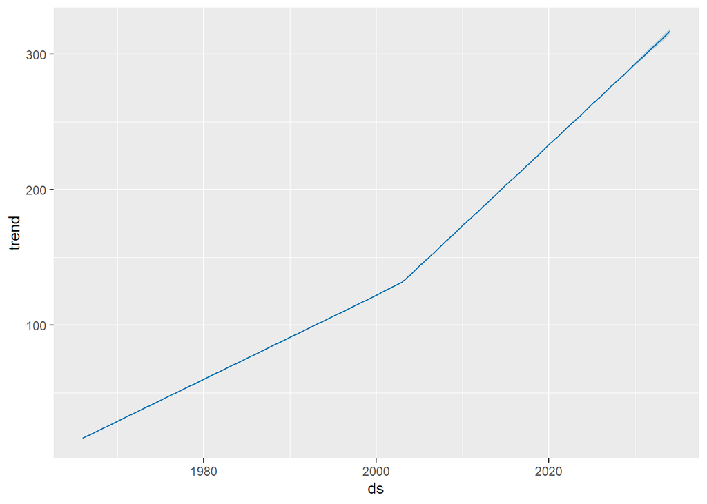

```r
prophet::prophet_plot_components(mclaren_prophet_model, mclaren_forecast)
```

# Section 6: Conclusion

The comparison between the flexible and rigid models in Section 5.2 showed that parameter choices matter. For a dataset as volatile as this one, a rigid trend just doesn’t capture the full story.

Prophet isn’t going to predict every twist in McLaren’s story, but it does a solid job of finding the overall direction. The forecast has McLaren staying competitive into the 2030s, which feels about right given where they are now.

Anyone who watches F1 knows a single regulation change can turn everything upside down though, so the wide uncertainty intervals make a lot of sense.

> Key takeaway 🚗: Meta’s Prophet is a powerful tool for modelling time series with complex trends. Even for data as volatile as F1 championship points, Prophet identifies the underlying trajectory and produces meaningful forecasts.

# References

- Formula 1 Constructor Standings: https://www.formula1.com/en/results/constructor-standings
- Meta Prophet documentation: https://facebook.github.io/prophet/
- McLaren F1 official website: https://www.mclaren.com/racing/